# Assignment 5 - Meta-analysis of pitch in schizophrenia

Riccardo Fusaroli

3/7/2019

# Building on the shoulders of giants: meta-analysis

## Questions to be answered

1. What is the current evidence for distinctive vocal patterns in schizophrenia? Report how many papers report quantitative estimates, comment on what percentage of the overall studies reviewed they represent (see PRISMA chart) your method to analyze them, the estimated effect size of the difference (mean effect size and standard error) and forest plots representing it. N.B. Only measures of pitch mean and pitch sd are required for the assignment (all the other measures have been removed from the dataset for the sake of simplicity).
2. Do the results match your own analysis from Assignment 3? If you add your results to the meta-analysis, do the estimated effect sizes change? Report the new estimates and the new forest plots.
3. Assess the quality of the literature: report and comment on heterogeneity of the studies (tau, I2), on publication bias (funnel plot), and on influential studies.

## Tips on the process to follow:

- Download the data on all published articles analyzing voice in schizophrenia and the prisma chart as reference of all articles found and reviewed Data: https://www.dropbox.com/s/0l9ur0gaabr80a8/Matrix_MetaAnalysis_Diagnosis_updated290719.xlsx?dl=0 Prisma chart: https://www.dropbox.com/s/vbjf6ff73dv9tru/PRISMA%202009%20flow%20diagram_PP.pptx?dl=0
- Look through the dataset to find out which columns to use, and if there is any additional information written as comments (real world data is always messy!).
  - Hint: PITCH_F0M and PITCH_F0SD group of variables are what you need
- Following the procedure in the slides calculate effect size and standard error of the effect size per each study. N.B. we focus on pitch mean and pitch standard deviation. . first try using lmer (to connect to what you know of mixed effects models) . then use rma() (to get some juicy additional statistics)

```r
# GUSTAV
# loading packages
pacman::p_load(lme4, lmerTest, readxl, tidyverse, metafor)
```

```r
# ANDERS
# loading meta analysis data
df <- read_excel('Matrix_MetaAnalysis_Diagnosis_updated290719.xlsx')
```

```
## * frequency -> frequency...68
## * frequency -> frequency...73
## * frequency -> frequency...78
## * frequency -> frequency...83
## * frequency -> frequency...88
## * ...
```

```r
#SIGRID
#### PREPPING COLUMNS IN DATAFRAME
df <- df %>%
  mutate(
    SAMPLE_SIZE_HC = as.numeric(SAMPLE_SIZE_HC),
    SAMPLE_SIZE_SZ = as.numeric(SAMPLE_SIZE_SZ),
    PITCH_F0_HC_M = as.numeric(PITCH_F0_HC_M),
    PITCH_F0_SZ_M = as.numeric(PITCH_F0_SZ_M),
    PITCH_F0_HC_SD = as.numeric(PITCH_F0_HC_SD),
    PITCH_F0_SZ_SD = as.numeric(PITCH_F0_SZ_SD),
    TYPE_OF_TASK = as.factor(TYPE_OF_TASK)
  ) %>%
  select(ArticleID, StudyID, Title, Authors, Year_publication, DIAGNOSIS, MALE_SZ, FEMALE_SZ, MALE_HC, FEMALE_HC, SAMPLE_SIZE_HC, SAMPLE_SIZE_SZ, TYPE_OF_TASK, PITCH_F0_HC_M, PITCH_F0_SZ_M, PITCH_F0_HC_SD, PITCH_F0_SZ_SD)
```

```r
############################# CALCULATING yi + vi ################################
# GUSTAV
# SMD = standardized mean difference, yi = observed effect size, vi = sampling variance
df <- escalc(
  measure = 'SMD',
  n1i = SAMPLE_SIZE_HC,
  n2i = SAMPLE_SIZE_SZ,
  m1i = PITCH_F0_HC_M,
  m2i = PITCH_F0_SZ_M,
  sd1i = PITCH_F0_HC_SD,
  sd2i = PITCH_F0_SZ_SD, data = df)
```

```r
############################## LMER MODELS ###############################
# ANDERS

m1_random <- lmer(yi ~ 1 + (1 | StudyID), weights = 1/vi, data=df, control=lmerControl(check.nobs.vs.nlev="ignore", check.nobs.vs.nRE="ignore"))
summary(m1_random)
```

```
## Linear mixed model fit by REML. t-tests use Satterthwaite's method [
## lmerModLmerTest]
## Formula: yi ~ 1 + (1 | StudyID)
##    Data: df
## Weights: 1/vi
## Control:
## lmerControl(check.nobs.vs.nlev = "ignore", check.nobs.vs.nRE = "ignore")
##
## REML criterion at convergence: 5.8
##
## Scaled residuals:
##        Min         1Q     Median         3Q        Max
## -0.0022761 -0.0011827 -0.0006473  0.0009493  0.0021579
##
## Random effects:
##  Groups   Name        Variance  Std.Dev.
##  StudyID  (Intercept) 1.295e-01 0.359808
##  Residual             5.472e-06 0.002339
## Number of obs: 6, groups:  StudyID, 6
##
## Fixed effects:
##             Estimate Std. Error      df t value Pr(>|t|)
## (Intercept)  -0.2065     0.1469  5.0000  -1.406    0.219
```

```r
m1_full <- lmer(yi ~ 1 + TYPE_OF_TASK + (1 | StudyID), weights = 1/vi, data=df, control=lmerControl(check.nobs.vs.nlev="ignore", check.nobs.vs.nRE="ignore"))
summary(m1_full)
```

```
## Linear mixed model fit by REML. t-tests use Satterthwaite's method [
## lmerModLmerTest]
## Formula: yi ~ 1 + TYPE_OF_TASK + (1 | StudyID)
##    Data: df
## Weights: 1/vi
## Control:
## lmerControl(check.nobs.vs.nlev = "ignore", check.nobs.vs.nRE = "ignore")
##
## REML criterion at convergence: 4.6
##
## Scaled residuals:
##        Min         1Q     Median         3Q        Max
## -0.0014862 -0.0005657 -0.0002657  0.0000000  0.0018983
##
## Random effects:
##  Groups   Name        Variance  Std.Dev.
##  StudyID  (Intercept) 1.734e-01 0.416405
##  Residual             5.912e-06 0.002431
## Number of obs: 6, groups:  StudyID, 6
##
## Fixed effects:
##                    Estimate Std. Error       df t value Pr(>|t|)
## (Intercept)        -0.27677    0.20820  3.00000  -1.329    0.276
## TYPE_OF_TASKFREE    0.02659    0.46555  3.00000   0.057    0.958
## TYPE_OF_TASKSOCIAL  0.39504    0.46555  3.00000   0.849    0.458
##
## Correlation of Fixed Effects:
##               (Intr) TYPE_OF_TASKF
## TYPE_OF_TASKF -0.447
## TYPE_OF_TASKS -0.447  0.200
## optimizer (nloptwrap) convergence code: 0 (OK)
## unable to evaluate scaled gradient
## Model failed to converge: degenerate  Hessian with 1 negative eigenvalues
```

- Build a forest plot of the results (forest(model))

```r
############################ RMA RANDOM EFFECTS MODEL ######################
# SIGRID

m2_random <-rma (yi, vi, data = df, slab = StudyID)
summary(m2_random)
```

```
##
## Random-Effects Model (k = 6; tau^2 estimator: REML)
##
##   logLik  deviance       AIC       BIC      AICc
##  -2.1749    4.3497    8.3497    7.5686   14.3497
##
## tau^2 (estimated amount of total heterogeneity): 0.0712 (SE = 0.0908)
## tau (square root of estimated tau^2 value):      0.2668
## I^2 (total heterogeneity / total variability):   50.29%
## H^2 (total variability / sampling variability):  2.01
##
## Test for Heterogeneity:
## Q(df = 5) = 9.8472, p-val = 0.0797
##
## Model Results:
##
## estimate      se     zval    pval    ci.lb   ci.ub
##  -0.1628  0.1554  -1.0476  0.2948  -0.4672  0.1417
##
## ---
## Signif. codes:  0 '***' 0.001 '**' 0.01 '*' 0.05 '.' 0.1 ' ' 1
```

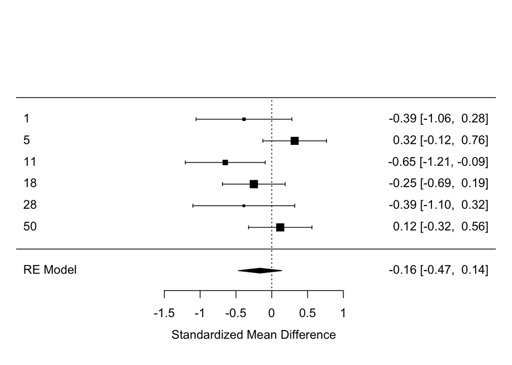

```r
# forest plot
forest(m2_random)
```

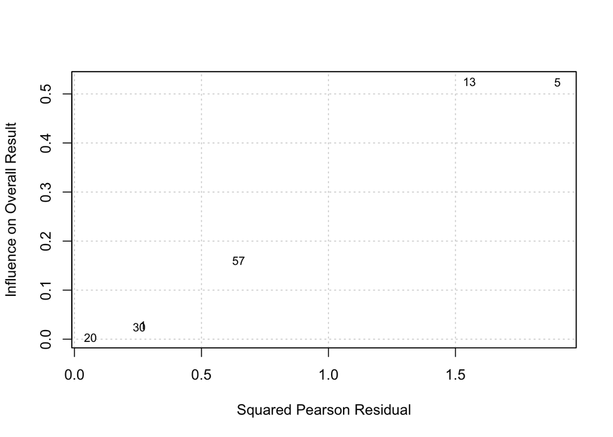

```r
# baujat plot
baujat(m2_random)
```

```r
############################ RMA FIXED EFFECTS MODEL ##################################
#GUSTAV

# model with fixed and random effects
m2_full <- rma(yi, vi, mods = cbind(TYPE_OF_TASK), data = df, slab=StudyID)
summary(m2_full)
```

```
##
## Mixed-Effects Model (k = 6; tau^2 estimator: REML)
##
##   logLik  deviance       AIC       BIC      AICc
##  -1.9572    3.9143    9.9143    8.0732   33.9143
##
## tau^2 (estimated amount of residual heterogeneity):     0.0924 (SE = 0.1201)
## tau (square root of estimated tau^2 value):             0.3040
## I^2 (residual heterogeneity / unaccounted variability): 55.34%
## H^2 (unaccounted variability / sampling variability):   2.24
## R^2 (amount of heterogeneity accounted for):            0.00%
##
## Test for Residual Heterogeneity:
## QE(df = 4) = 9.0272, p-val = 0.0604
##
## Test of Moderators (coefficient 2):
## QM(df = 1) = 0.5154, p-val = 0.4728
##
## Model Results:
##
##               estimate      se     zval    pval    ci.lb   ci.ub
## intrcpt        -0.4067  0.3718  -1.0940  0.2740  -1.1354  0.3220
## TYPE_OF_TASK    0.1507  0.2099   0.7179  0.4728  -0.2607  0.5621
##
## ---
## Signif. codes:  0 '***' 0.001 '**' 0.01 '*' 0.05 '.' 0.1 ' ' 1
```

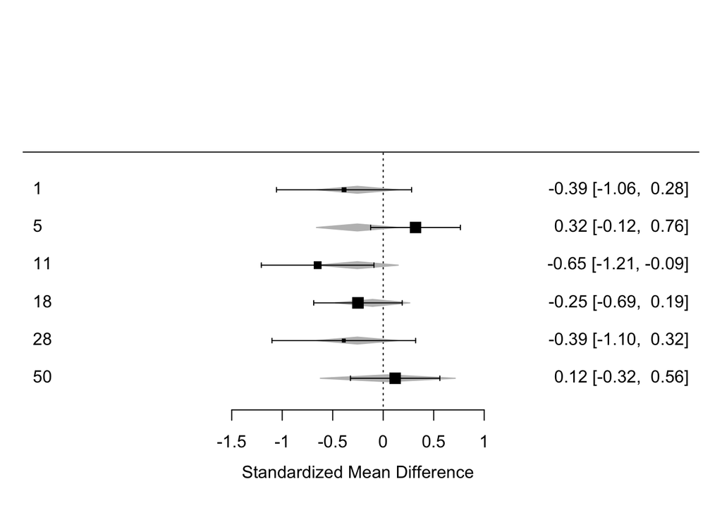

```r
#forest plot
forest(m2_full)
```

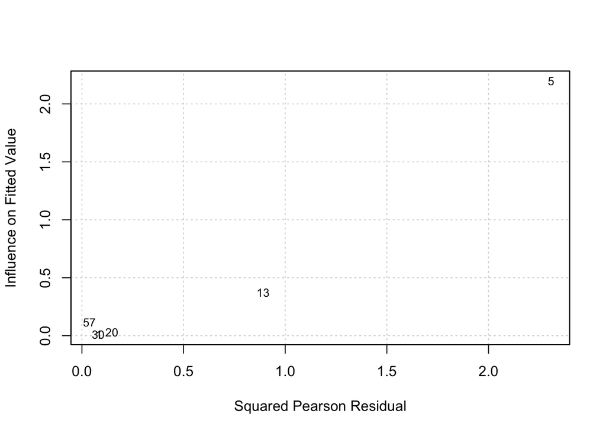

```r
#baujat plot
baujat(m2_full)
```

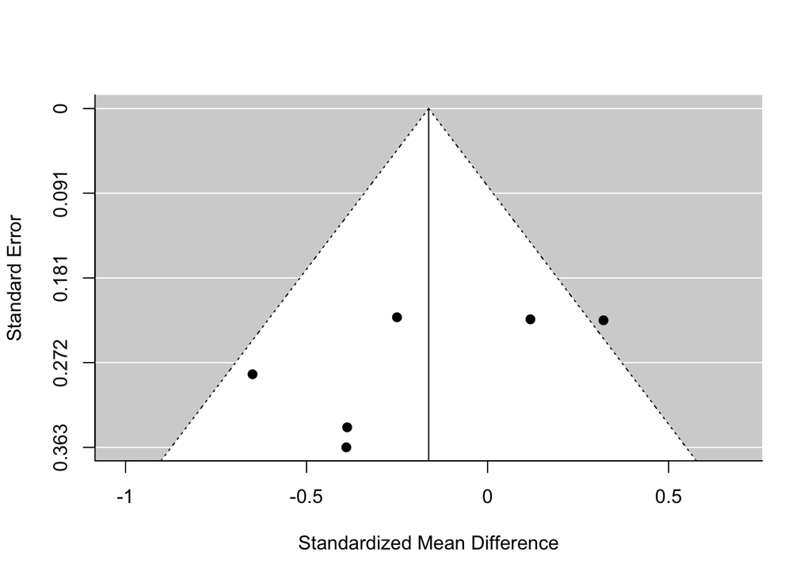

```r
########################### FUNNEL PLOT AND NUMERIC TEST ##############################
# ANDERS

#funnel plots
funnel(m2_random)
```

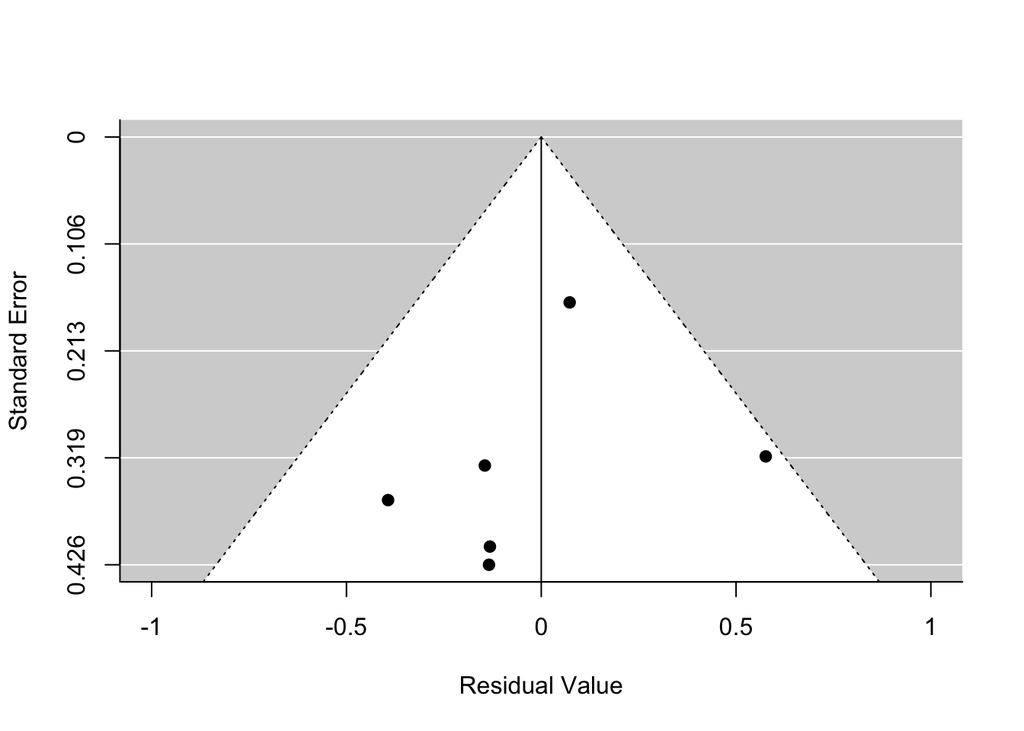

```r
funnel(m2_full)
```

```r
#numeric tests
# regression model test
regtest(m2_random)
```

```
##
## Regression Test for Funnel Plot Asymmetry
##
## model:     mixed-effects meta-regression model
## predictor: standard error
##
## test for funnel plot asymmetry: z = -1.5798, p = 0.1142
```

```r
regtest(m2_full)
```

```
##
## Regression Test for Funnel Plot Asymmetry
##
## model:     mixed-effects meta-regression model
## predictor: standard error
##
## test for funnel plot asymmetry: z = -1.1308, p = 0.2581
```

```r
# correlation test - Kendall's Tau
ranktest(m2_random)
```

```
##
## Rank Correlation Test for Funnel Plot Asymmetry
##
## Kendall's tau = -0.2000, p = 0.7194
```

```r
ranktest(m2_full)
```

```
##
## Rank Correlation Test for Funnel Plot Asymmetry
##
## Kendall's tau = -0.2000, p = 0.7194
```

- Go back to Assignment 3, add your own study to the data table, and re-run meta-analysis. Do the results change?

```r
# SIGRID
#loading dataset from assignment 3
data_3 <- read_csv("FINAL_DATA_A3.csv")
############### ADDING STUDY FROM PORTFOLIO 3 TO THE DF #############################
# GUSTAV
#these dataframes contain values which are then added to the df
gender_diagnosis_data_3 <- data_3 %>%
  group_by(Gender, Diagnosis) %>%
  summarize(length(unique(New_id)))
sample_size_data_3 <- data_3 %>%
  group_by(Diagnosis) %>%
  summarize(length(unique(New_id)))
pitch_mean_data_3 <- data_3 %>%
  group_by(Diagnosis) %>%
  summarize(mean(mean))
pitch_sd_data_3 <- data_3 %>%
  group_by(Diagnosis) %>%
  summarize(sd(mean))
#adding a new row with the study from assignment 3
df <- as_tibble(df) %>%
  add_row(ArticleID = 49,
          StudyID = 51,
          Title = 'Voice Patterns in Schizophrenia: A systematic Review and Bayesian Meta-Analysis',
          Authors = 'Parola Alberto, Simonsen Arndis, Bliksted Vibeke, Fusaroli Riccardo',
          DIAGNOSIS = "SZ",
          MALE_SZ = '73',
          FEMALE_SZ = '63',
          MALE_HC = '90',
          FEMALE_HC = '69',
          SAMPLE_SIZE_HC = 160,
          SAMPLE_SIZE_SZ = 136,
          TYPE_OF_TASK = "CONSTR",
          PITCH_F0_HC_M = 156.8,
          PITCH_F0_SZ_M = 167.0,
          PITCH_F0_HC_SD = 59.2,
          PITCH_F0_SZ_SD = 55.2
          )
```

```r
############################# CALCULATING NEW VI + YI ########################
# ANDERS

df3 <- df %>% escalc(
  measure = 'SMD',
  n1i = SAMPLE_SIZE_HC,
  n2i = SAMPLE_SIZE_SZ,
  m1i = PITCH_F0_HC_M,
  m2i = PITCH_F0_SZ_M,
  sd1i = PITCH_F0_HC_SD,
  sd2i = PITCH_F0_SZ_SD, data = df)


df3$TYPE_OF_TASK <- as.factor(df3$TYPE_OF_TASK)
```

- Now look at the output of rma() and check tau and I2

```r
################ USING RMA (INCLUDING THE DATA FROM PORT 3) ###########################
# SIGRID

# first model with only random effects
m3_random <- rma(yi, vi, data = df3, slab = StudyID)
summary(m3_random)
```

```
##
## Random-Effects Model (k = 7; tau^2 estimator: REML)
##
##   logLik  deviance       AIC       BIC      AICc
##  -1.7951    3.5903    7.5903    7.1738   11.5903
##
## tau^2 (estimated amount of total heterogeneity): 0.0358 (SE = 0.0516)
## tau (square root of estimated tau^2 value):      0.1892
## I^2 (total heterogeneity / total variability):   41.42%
## H^2 (total variability / sampling variability):  1.71
##
## Test for Heterogeneity:
## Q(df = 6) = 9.9648, p-val = 0.1261
##
## Model Results:
##
## estimate      se     zval    pval    ci.lb   ci.ub
##  -0.1567  0.1147  -1.3658  0.1720  -0.3816  0.0682
##
## ---
## Signif. codes:  0 '***' 0.001 '**' 0.01 '*' 0.05 '.' 0.1 ' ' 1
```

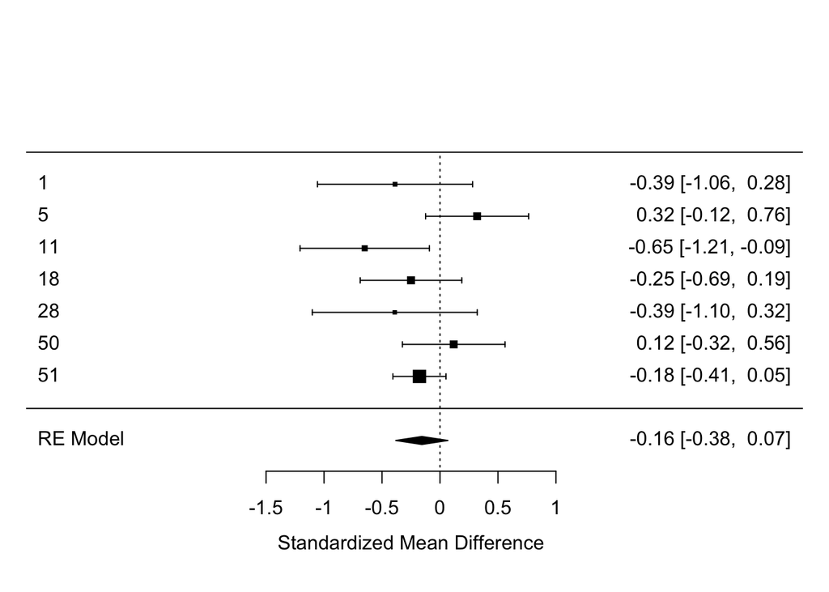

```r
# forest plot
forest(m3_random)
```

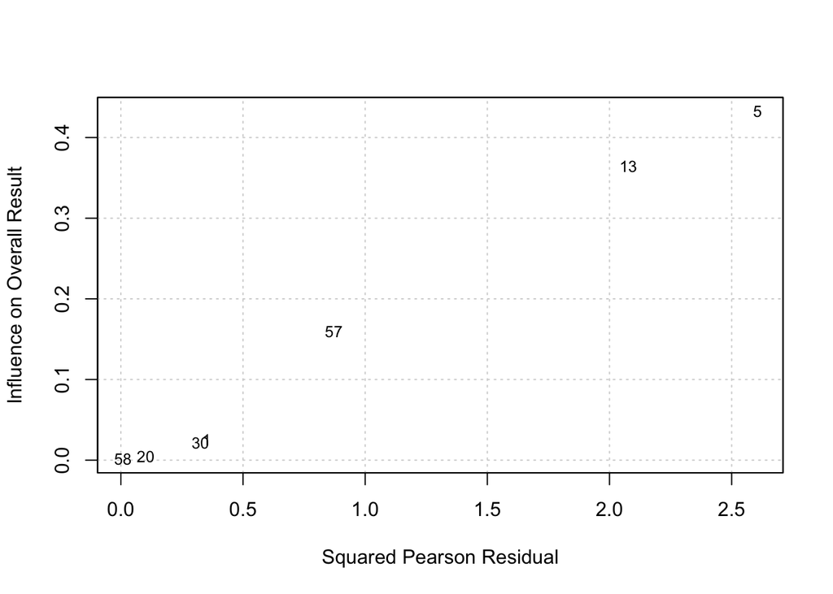

```r
# baujat plot
baujat(m3_random)
```

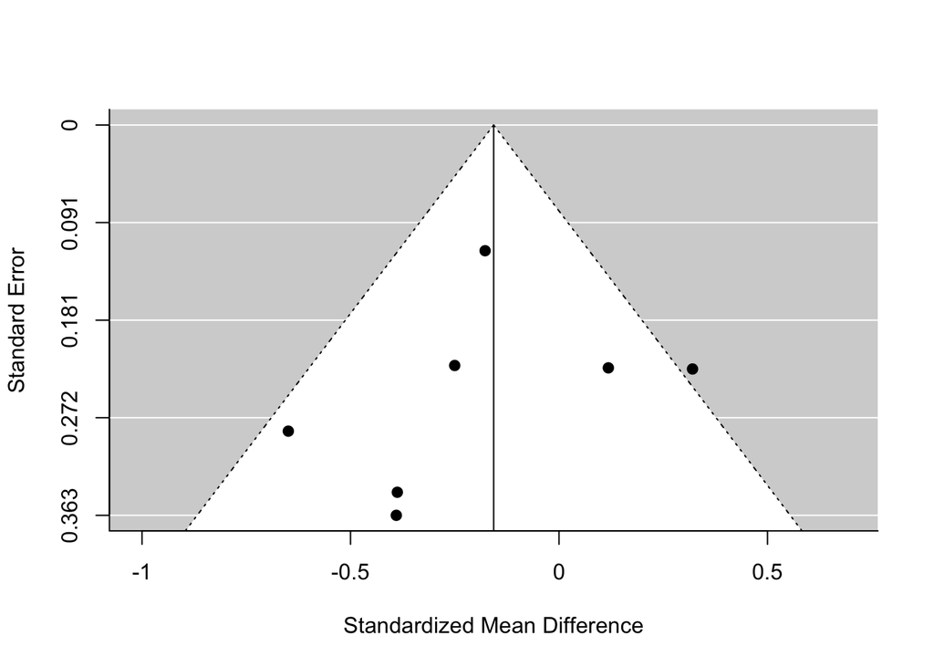

```r
# Funnel plot
funnel(m3_random)
```

```r
# second model with random and mixed effects
m3_full <- rma(yi, vi, mods = cbind(TYPE_OF_TASK), data = df3, slab=StudyID)
summary(m3_full)
```

```
##
## Mixed-Effects Model (k = 7; tau^2 estimator: REML)
##
##   logLik  deviance       AIC       BIC      AICc
##  -1.7335    3.4669    9.4669    8.2952   33.4669
##
## tau^2 (estimated amount of residual heterogeneity):     0.0510 (SE = 0.0692)
## tau (square root of estimated tau^2 value):             0.2259
## I^2 (residual heterogeneity / unaccounted variability): 48.53%
## H^2 (unaccounted variability / sampling variability):   1.94
## R^2 (amount of heterogeneity accounted for):            0.00%
##
## Test for Residual Heterogeneity:
## QE(df = 5) = 9.0475, p-val = 0.1072
##
## Test of Moderators (coefficient 2):
## QM(df = 1) = 0.5952, p-val = 0.4404
##
## Model Results:
##
##               estimate      se     zval    pval    ci.lb   ci.ub
## intrcpt        -0.3504  0.2753  -1.2725  0.2032  -0.8900  0.1893
## TYPE_OF_TASK    0.1295  0.1678   0.7715  0.4404  -0.1995  0.4584
##
## ---
## Signif. codes:  0 '***' 0.001 '**' 0.01 '*' 0.05 '.' 0.1 ' ' 1
```

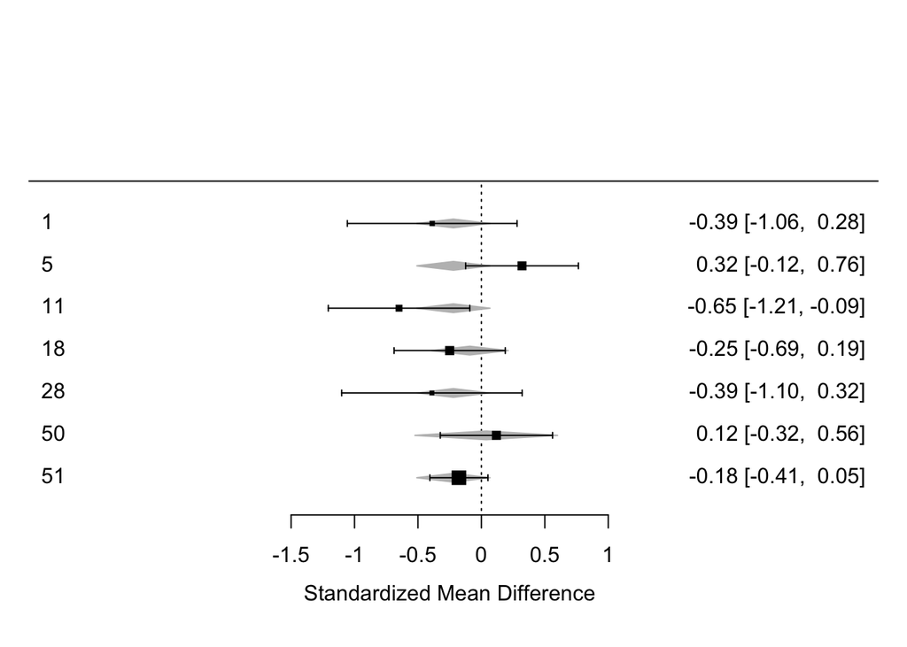

```r
# forest plot
forest(m3_full)
```

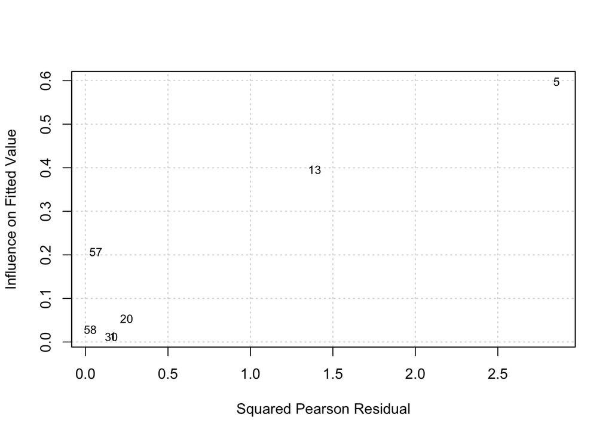

```r
# baujat plot
baujat(m3_full)
```